# Prosper Loan Data Exploration

## by (Cynthia Nakaoka)

## Investigation Overview

> This data exploration was focused on analyzing the indicators that could increase a borrower's chances of getting a loan. Another point in focus was the other side of who lends the money, in this case, check which borrower features are best for predicting the highest rate of return.

## Dataset Overview

> This Prosper's [data set](https://docs.google.com/document/d/e/2PACX-1vQmkX4iOT6Rcrin42vslquX2_wQCjIa_hbwD0xmxrERPSOJYDtpNc_3wwK_p9_KpOsfA6QVyEHdxxq7/pub) contains 113,937 loans with 81 variables on each loan, including loan amount, borrower rate (or interest rate), current loan status, borrower income, and many others. The data dictionary that explains the variables in the data set you can find [here](https://docs.google.com/spreadsheets/d/1gDyi_L4UvIrLTEC6Wri5nbaMmkGmLQBk-Yx3z0XDEtI/edit#gid=0)

## Actual Return distribution

> There are small amounts of total loan loss and a large spike of zero-to-zero situations in relation to financial returns. There are two large returns concentration in the 0% - 50% ranges and one in the 100% to 170% return ranges.

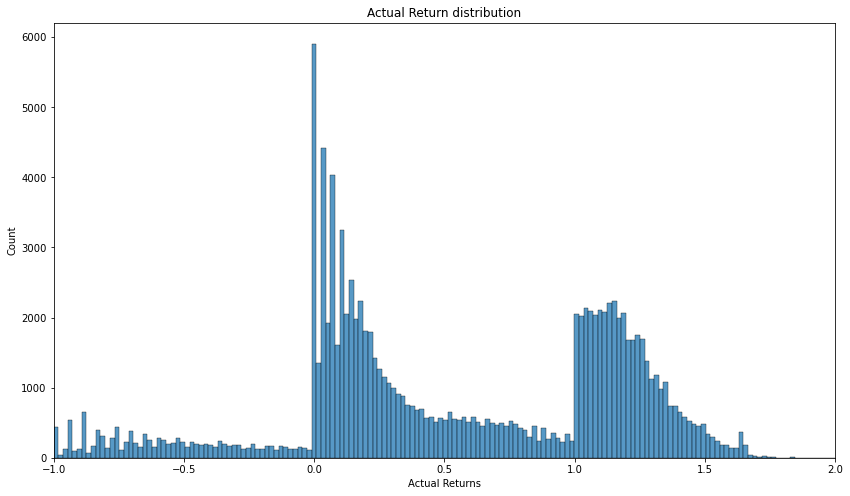

## Actual Return by Income Range and Term

> In the separation of Actual Retruns by Income Range and Term, there is a clear separation of Return by loan time. The time that brought the most current returns was 36 months, then 60 months and the one that brought the least return was 12 months.

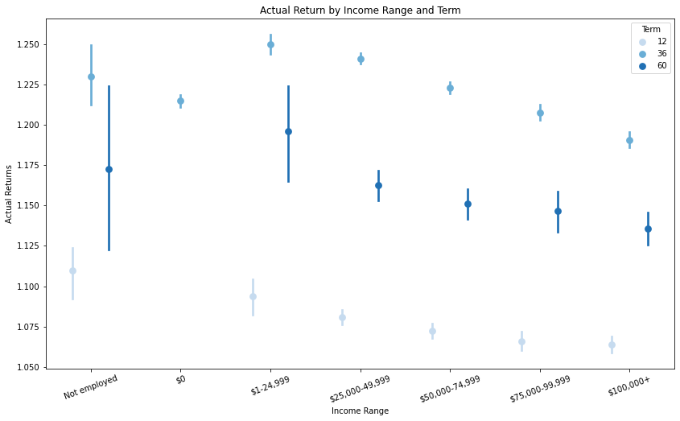

## Actual Return by Prosper Rating and Term

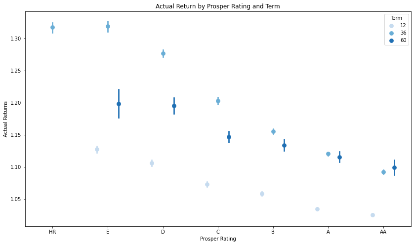

## Estimated Returns by Prosper Score and Income Range

> There is a strong correlation between Estimated Return by income range.Being Not employed, without remuneration or have a salary until 24,999 dollars have average expected return being higher than the other salary ranges.

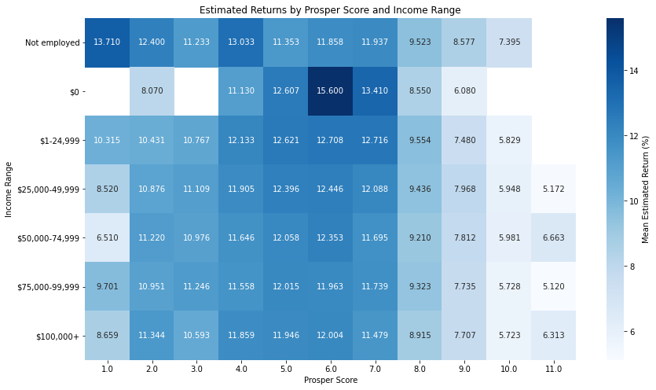

## Loan Original Amount by Prosper Rating and term

> There is a strong correlation of approved loans with the original Loan amount, monthly income and term. Prosper Rating appears to have a positive variation from mild to moderate when compared to other features.

> Over the lifespan of 60-month loans there is a significant increase in the original loan amount as ratings improve. This relationship weakens when the Term decreases.

> Most of Loans have Loan Original amount above 4,000 dollars.

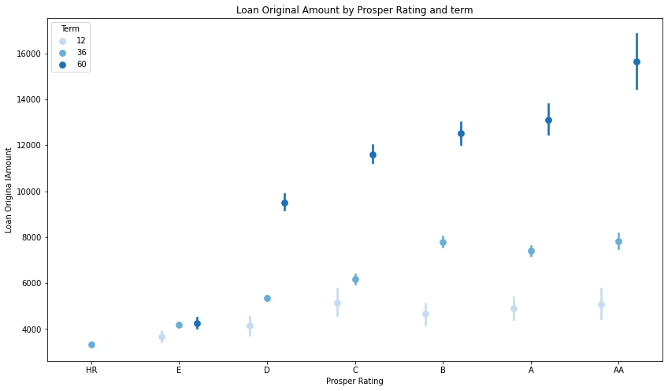

## Monthly Income by Prosper Rating and Term

> There is a strong correlation of approved loans with monthly income and prosper rating. The higher the monthly income, the higher the rating is.

> In the data analysis it was verified that all Approved Loans had a monthly income above 3,000 dollars

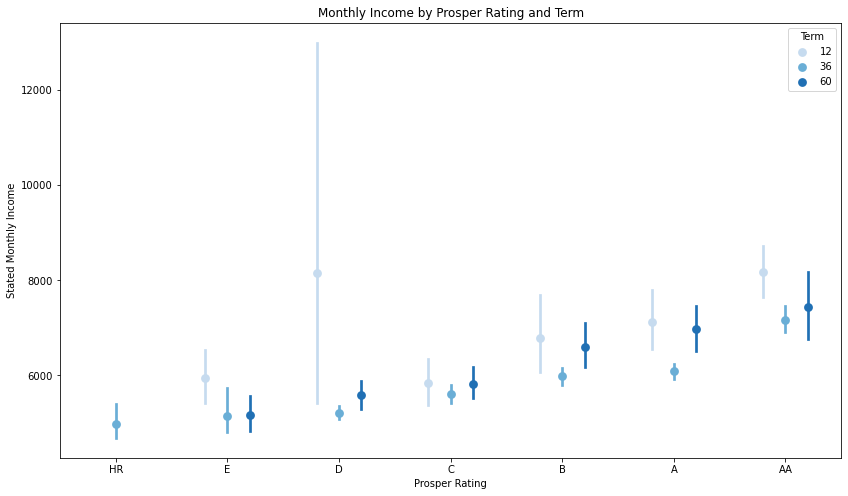

## Employment Status by Prosper rating

> The vast majority of approved loan applications are from people who are employed or work full-time. The distribution of prosper rating who works less than full time is very uniform in all bands. For those who are employed, the classes with the highest volume of loans are in the D, C, B and A ranges.

> The characteristic of volume of approved loans from those who are not employed is that they are concentrated in ratings considered to be lower and as the rating gets better, the number of approvals decreases.

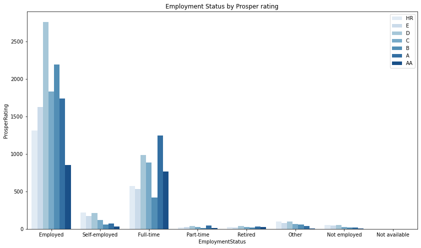

## Debt To Income Ratio

> The average Debt To Income Ratio is 26% and the graph od this distribution is right skewed. We can notice a growing drop in the number of people who have a ratio greater than 20%.

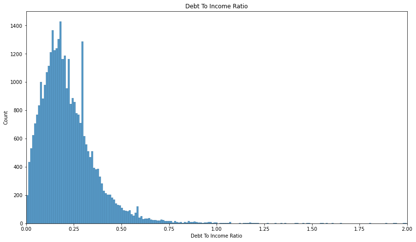